# coggshall_jacob_final_project

Jacob Coggshall

2022-11-23

#### Step #1: Set global options and load packages

#### Step #2: Import water use data; clean data

**Q1:What data are you using**

I am using data on deep percolation, pumping, and agricultral area.

**Q2: Where are the data from**

I got this data from the California Department of Water Resources

**Q3:Using these data, what figures will you make**

**Q4:What is the main point of each of your figures**

**Q5: Why did you choose the data you chose? Why did you choose the topic you chose?**

I chose this data because I thought that the story it would tell would be really interesting, and that it would be relevant living in California and learning about how the central valley is affected by drought and overdrawing of our water resources.

**Q6: In what ways are you hoping this project challenges you?**

I chose this data because I thought it would really challenge me.I like how there is just so much data to use, that I had to comb through a government report to find out what the data on the excel sheet meant, and that I have to combine these 21 seperate sheets into specifc regions twice, once for the percolation and pumping, and once for the land area. I struggled with the second access and second line in lab 7 as well, so I wanted to do it again so I could get better at it.

```r
#Regions 1-7 make up the Sacramento River Basin. Reading excel file sheet by sheet for the different regions

water_reg_1 <- read_excel(here("data/1921_2009_Groundwater_budget.xlsx"), skip = 3, sheet = 1) |>
  clean_names()|>                                                       #Selecting deep percolation and pumping data and cleaning the names
  select(time, deep_percolation, pumping)

water_reg_2 <- read_excel(here("data/1921_2009_Groundwater_budget.xlsx"), skip = 3, sheet = 2)|>
  clean_names()|>                                                       #Selecting deep percolation and pumping data and cleaning the names
  select(time, deep_percolation, pumping)

water_reg_3 <- read_excel(here("data/1921_2009_Groundwater_budget.xlsx"), skip = 3, sheet = 3)|>
  clean_names()|>                                                       #Selecting deep percolation and pumping data and cleaning the names
  select(time, deep_percolation, pumping)

water_reg_4 <- read_excel(here("data/1921_2009_Groundwater_budget.xlsx"), skip = 3, sheet = 4)|>
  clean_names()|>                                                       #Selecting deep percolation and pumping data and cleaning the names
  select(time, deep_percolation, pumping)

water_reg_5 <- read_excel(here("data/1921_2009_Groundwater_budget.xlsx"), skip = 3, sheet = 5)|>
  clean_names()|>                                                       #Selecting deep percolation and pumping data and cleaning the names
  select(time, deep_percolation, pumping)

water_reg_6 <- read_excel(here("data/1921_2009_Groundwater_budget.xlsx"), skip = 3, sheet = 6)|>
  clean_names()|>                                                       #Selecting deep percolation and pumping data and cleaning the names
  select(time, deep_percolation, pumping)

water_reg_7 <- read_excel(here("data/1921_2009_Groundwater_budget.xlsx"), skip = 3, sheet = 7)|>
  clean_names()|>                                                       #Selecting deep percolation and pumping data and cleaning the names
  select(time, deep_percolation, pumping)

#Regions 8-13 make up the San Joaquin River Basin. Reading excel file sheet by sheet for the different regions

water_reg_8 <- read_excel(here("data/1921_2009_Groundwater_budget.xlsx"), skip = 3, sheet = 8)|>
  clean_names()|>                                                       #Selecting deep percolation and pumping data and cleaning the names
  select(time, deep_percolation, pumping)

water_reg_9 <- read_excel(here("data/1921_2009_Groundwater_budget.xlsx"), skip = 3, sheet = 9)|>
  clean_names()|>                                                       #Selecting deep percolation and pumping data and cleaning the names
  select(time, deep_percolation, pumping)

water_reg_10 <- read_excel(here("data/1921_2009_Groundwater_budget.xlsx"), skip = 3, sheet = 10)|>
  clean_names()|>                                                       #Selecting deep percolation and pumping data and cleaning the names
  select(time, deep_percolation, pumping)

water_reg_11 <- read_excel(here("data/1921_2009_Groundwater_budget.xlsx"), skip = 3, sheet = 11)|>
  clean_names()|>                                                       #Selecting deep percolation and pumping data and cleaning the names
  select(time, deep_percolation, pumping)

water_reg_12 <- read_excel(here("data/1921_2009_Groundwater_budget.xlsx"), skip = 3, sheet = 12)|>
  clean_names()|>                                                       #Selecting deep percolation and pumping data and cleaning the names
  select(time, deep_percolation, pumping)

water_reg_13 <- read_excel(here("data/1921_2009_Groundwater_budget.xlsx"), skip = 3, sheet = 13)|>
  clean_names()|>                                                       #Selecting deep percolation and pumping data and cleaning the names
  select(time, deep_percolation, pumping)

#Regions 1-7 make up the Tulare Basin. Reading excel file sheet by sheet for the different regions.

water_reg_14 <- read_excel(here("data/1921_2009_Groundwater_budget.xlsx"), skip = 3, sheet = 14)|>
  clean_names()|>                                                       #Selecting deep percolation and pumping data and cleaning the names
  select(time, deep_percolation, pumping)

water_reg_15 <- read_excel(here("data/1921_2009_Groundwater_budget.xlsx"), skip = 3, sheet = 15)|>
  clean_names()|>                                                       #Selecting deep percolation and pumping data and cleaning the names
  select(time, deep_percolation, pumping)

water_reg_16 <- read_excel(here("data/1921_2009_Groundwater_budget.xlsx"), skip = 3, sheet = 16)|>
  clean_names()|>                                                       #Selecting deep percolation and pumping data and cleaning the names
  select(time, deep_percolation, pumping)

water_reg_17 <- read_excel(here("data/1921_2009_Groundwater_budget.xlsx"), skip = 3, sheet = 17)|>
  clean_names()|>                                                       #Selecting deep percolation and pumping data and cleaning the names
  select(time, deep_percolation, pumping)

water_reg_18 <- read_excel(here("data/1921_2009_Groundwater_budget.xlsx"), skip = 3, sheet = 18)|>
  clean_names()|>                                                       #Selecting deep percolation and pumping data and cleaning the names
  select(time, deep_percolation, pumping)

water_reg_19 <- read_excel(here("data/1921_2009_Groundwater_budget.xlsx"), skip = 3, sheet = 19)|>
  clean_names()|>                                                       #Selecting deep percolation and pumping data and cleaning the names
  select(time, deep_percolation, pumping)

water_reg_20 <- read_excel(here("data/1921_2009_Groundwater_budget.xlsx"), skip = 3, sheet = 20)|>
  clean_names()|>                                                       #Selecting deep percolation and pumping data and cleaning the names
  select(time, deep_percolation, pumping)

water_reg_21 <- read_excel(here("data/1921_2009_Groundwater_budget.xlsx"), skip = 3, sheet = 21)|>
  clean_names()|>                                                       #Selecting deep percolation and pumping data and cleaning the names
  select(time, deep_percolation, pumping)


#Regions 1-7 make up the Sacramento River Basins agricultural land. Reading excel file sheet by sheet for the different regions

ag_reg_1 <- read_excel(here("data/1921_2009_Land_water_use_budget.xlsx"), skip = 3, sheet = 1) |>
  clean_names() |>                                                       #Selecting agricultural area data and cleaning the names
  select(time, ag_area_ac)

ag_reg_2 <- read_excel(here("data/1921_2009_Land_water_use_budget.xlsx"), skip = 3, sheet = 2) |>
  clean_names()|>                                                       #Selecting agricultural area data and cleaning the names
  select(time, ag_area_ac)

ag_reg_3 <- read_excel(here("data/1921_2009_Land_water_use_budget.xlsx"), skip = 3, sheet = 3) |>
  clean_names()|>                                                       #Selecting agricultural area data and cleaning the names
  select(time, ag_area_ac)

ag_reg_4 <- read_excel(here("data/1921_2009_Land_water_use_budget.xlsx"), skip = 3, sheet = 4) |>
  clean_names()|>                                                       #Selecting agricultural area data and cleaning the names
  select(time, ag_area_ac)

ag_reg_5 <- read_excel(here("data/1921_2009_Land_water_use_budget.xlsx"), skip = 3, sheet = 5) |>
  clean_names()|>                                                       #Selecting agricultural area data and cleaning the names
  select(time, ag_area_ac)

ag_reg_6 <- read_excel(here("data/1921_2009_Land_water_use_budget.xlsx"), skip = 3, sheet = 6) |>
  clean_names()|>                                                       #Selecting agricultural area data and cleaning the names
  select(time, ag_area_ac)

ag_reg_7 <- read_excel(here("data/1921_2009_Land_water_use_budget.xlsx"), skip = 3, sheet = 7) |>
  clean_names()|>                                                       #Selecting agricultural area data and cleaning the names
  select(time, ag_area_ac)

#Regions 8-13 make up the San Joaquin River Basins agricultural land. Reading excel file sheet by sheet for the different regions

ag_reg_8 <- read_excel(here("data/1921_2009_Land_water_use_budget.xlsx"), skip = 3, sheet = 8) |>
  clean_names()|>                                                       #Selecting agricultural area data and cleaning the names
  select(time, ag_area_ac)

ag_reg_9 <- read_excel(here("data/1921_2009_Land_water_use_budget.xlsx"), skip = 3, sheet = 9) |>
  clean_names()|>                                                       #Selecting agricultural area data and cleaning the names
  select(time, ag_area_ac)

ag_reg_10 <- read_excel(here("data/1921_2009_Land_water_use_budget.xlsx"), skip = 3, sheet = 10) |>
  clean_names()|>                                                       #Selecting agricultural area data and cleaning the names
  select(time, ag_area_ac)

ag_reg_11 <- read_excel(here("data/1921_2009_Land_water_use_budget.xlsx"), skip = 3, sheet = 11) |>
  clean_names()|>                                                       #Selecting agricultural area data and cleaning the names
  select(time, ag_area_ac)

ag_reg_12 <- read_excel(here("data/1921_2009_Land_water_use_budget.xlsx"), skip = 3, sheet = 12) |>
  clean_names()|>                                                       #Selecting agricultural area data and cleaning the names
  select(time, ag_area_ac)

ag_reg_13 <- read_excel(here("data/1921_2009_Land_water_use_budget.xlsx"), skip = 3, sheet = 13) |>
  clean_names()|>                                                       #Selecting agricultural area data and cleaning the names
  select(time, ag_area_ac)

#Regions 14-21 make up the Tulare Basins agricultural land. Reading excel file sheet by sheet for the different regions

ag_reg_14 <- read_excel(here("data/1921_2009_Land_water_use_budget.xlsx"), skip = 3, sheet = 14) |>
  clean_names()|>                                                       #Selecting agricultural area data and cleaning the names
  select(time, ag_area_ac)

ag_reg_15 <- read_excel(here("data/1921_2009_Land_water_use_budget.xlsx"), skip = 3, sheet = 15) |>
  clean_names()|>                                                       #Selecting agricultural area data and cleaning the names
  select(time, ag_area_ac)

ag_reg_16 <- read_excel(here("data/1921_2009_Land_water_use_budget.xlsx"), skip = 3, sheet = 16) |>
  clean_names()|>                                                       #Selecting agricultural area data and cleaning the names
  select(time, ag_area_ac)

ag_reg_17 <- read_excel(here("data/1921_2009_Land_water_use_budget.xlsx"), skip = 3, sheet = 17) |>
  clean_names()|>                                                       #Selecting agricultural area data and cleaning the names
  select(time, ag_area_ac)

ag_reg_18 <- read_excel(here("data/1921_2009_Land_water_use_budget.xlsx"), skip = 3, sheet = 18) |>
  clean_names()|>                                                       #Selecting agricultural area data and cleaning the names
  select(time, ag_area_ac)

ag_reg_19 <- read_excel(here("data/1921_2009_Land_water_use_budget.xlsx"), skip = 3, sheet = 19) |>
  clean_names()|>                                                       #Selecting agricultural area data and cleaning the names
  select(time, ag_area_ac)

ag_reg_20 <- read_excel(here("data/1921_2009_Land_water_use_budget.xlsx"),skip = 3, sheet = 20) |>
  clean_names()|>                                                       #Selecting agricultural area data and cleaning the names
  select(time, ag_area_ac)

ag_reg_21 <- read_excel(here("data/1921_2009_Land_water_use_budget.xlsx"), skip = 3, sheet = 21) |>
  clean_names()|>                                                       #Selecting agricultural area data and cleaning the names
  select(time, ag_area_ac)
```

#### Step #3: Organize data for our Sacramento River Basin plot

```r
#Getting the Sacramento River Basin Data ready for Plotting

sac_riv_basin <- rbind(water_reg_1,                    #Consolidating the regions into one object for the Sacramento River Basin
                      water_reg_2,
                      water_reg_3,
                      water_reg_4,
                      water_reg_5,
                      water_reg_6,
                      water_reg_7)|>
  group_by(time) |>                                    #Grouping by time so we can consolidate our observations
  summarize_at(vars(1:2), sum, na.rm = TRUE) |>        #Consolidating our observations
  ungroup()                                            #Ungrouping to return our time column

sac_riv_1920_1930_perc <- sac_riv_basin|>                #Creating an object on percolation for a ten year span for our timeseries plot
    group_by(time)|>                                   #Grouping by year specifically for percolation data
  summarize_at(vars(1), sum, na.rm = TRUE)|>           #Summarizing our data so we can pivot our object to select our 10 year period
  pivot_wider(names_from = "time",                     #Pivoting or data so we can select just the years we want
              values_from = deep_percolation)|>        #Setting where we want our names and values from
  clean_names()|>                                      #Cleaning the name of our columns
  select(contains("x192"))|>                           #Selecting the columns with the first three digits of the year for our 10 years
  pivot_longer(cols = 1:99,                            #Selecting which columns to pivot
               names_to = "time",                      #Pivoting our columns os we can summarize the data
               values_to = "deep_percolation")|>       #Setting where we want our names and values to go
  distinct(deep_percolation)|>                                      #Getting rid of our time column
  summarize_at(vars(1), sum, na.rm = TRUE)             #Summarizing our column leaving a single value for 10 years of net percolation

sac_riv_1920_1930_pump <- sac_riv_basin|>                #Creating an object on pumping for a ten year span for our timeseries plot
    group_by(time)|>                                   #Grouping by year specifically for pumping data
  summarize_at(vars(2), sum, na.rm = TRUE)|>           #Summarizing our data so we can pivot our object to select our 10 year period
  pivot_wider(names_from = "time",                     #Pivoting or data so we can select just the years we want
              values_from = pumping)|>                 #Setting where we want our names and values from
  clean_names()|>                                      #Cleaning the name of our columns
  select(contains("x192"))|>                           #Selecting the columns with the first three digits of the year for our 10 years
  pivot_longer(cols = 1:99,                            #Selecting which columns to pivot
               names_to = "time",                      #Pivoting our columns os we can summarize the data
               values_to = "pumping")|>                #Setting where we want our names and values to go
  distinct(pumping)|>                                      #Getting rid of our time column
  summarize_at(vars(1), sum, na.rm = TRUE)|>           #Summarizing our column leaving a single value for 10 years of net percolation
  mutate(year = 1920)                                  #Adding in a new column for year

sac_riv_1920_1930 <- cbind(sac_riv_1920_1930_perc,       #Combining our year, percolation, pumping data for the year
                       sac_riv_1920_1930_pump)

  #Selecting and combing the data only from 1930-1940 year span for plotting

sac_riv_1930_1940_perc <- sac_riv_basin|>                #Creating an object on percolation for a ten year span for our timeseries plot
    group_by(time)|>                                   #Grouping by year specifically for percolation data
  summarize_at(vars(1), sum, na.rm = TRUE)|>           #Summarizing our data so we can pivot our object to select our 10 year period
  pivot_wider(names_from = "time",                     #Pivoting or data so we can select just the years we want
              values_from = deep_percolation)|>        #Setting where we want our names and values from
  clean_names()|>                                      #Cleaning the name of our columns
  select(contains("x193"))|>                           #Selecting the columns with the first three digits of the year for our 10 years
  pivot_longer(cols = 1:120,                            #Selecting which columns to pivot
               names_to = "time",                      #Pivoting our columns os we can summarize the data
               values_to = "deep_percolation")|>       #Setting where we want our names and values to go
  distinct(deep_percolation)|>                                      #Getting rid of our time column
  summarize_at(vars(1), sum, na.rm = TRUE)             #Summarizing our column leaving a single value for 10 years of net percolation

sac_riv_1930_1940_pump <- sac_riv_basin|>                #Creating an object on pumping for a ten year span for our timeseries plot
    group_by(time)|>                                   #Grouping by year specifically for pumping data
  summarize_at(vars(2), sum, na.rm = TRUE)|>           #Summarizing our data so we can pivot our object to select our 10 year period
  pivot_wider(names_from = "time",                     #Pivoting or data so we can select just the years we want
              values_from = pumping)|>                 #Setting where we want our names and values from
  clean_names()|>                                      #Cleaning the name of our columns
  select(contains("x193"))|>                           #Selecting the columns with the first three digits of the year for our 10 years
  pivot_longer(cols = 1:120,                            #Selecting which columns to pivot
               names_to = "time",                      #Pivoting our columns os we can summarize the data
               values_to = "pumping")|>                #Setting where we want our names and values to go
  distinct(pumping)|>                                      #Getting rid of our time column
  summarize_at(vars(1), sum, na.rm = TRUE)|>           #Summarizing our column leaving a single value for 10 years of net percolation
  mutate(year = 1930)                                  #Adding in a new column for year
```

```r
sac_riv_1930_1940 <- cbind(sac_riv_1930_1940_perc,       #Combining our year, percolation, pumping data for the year
                       sac_riv_1930_1940_pump)

#Selecting and combing the data only from 1940-1950 year span for plotting

sac_riv_1940_1950_perc <- sac_riv_basin|>                #Creating an object on percolation for a ten year span for our timeseries plot
    group_by(time)|>                                   #Grouping by year specifically for percolation data
  summarize_at(vars(1), sum, na.rm = TRUE)|>           #Summarizing our data so we can pivot our object to select our 10 year period
  pivot_wider(names_from = "time",                     #Pivoting or data so we can select just the years we want
              values_from = deep_percolation)|>        #Setting where we want our names and values from
  clean_names()|>                                      #Cleaning the name of our columns
  select(contains("x194"))|>                           #Selecting the columns with the first three digits of the year for our 10 years
  pivot_longer(cols = 1:120,                            #Selecting which columns to pivot
               names_to = "time",                      #Pivoting our columns os we can summarize the data
               values_to = "deep_percolation")|>       #Setting where we want our names and values to go
  distinct(deep_percolation)|>                                      #Getting rid of our time column
  summarize_at(vars(1), sum, na.rm = TRUE)             #Summarizing our column leaving a single value for 10 years of net percolation

sac_riv_1940_1950_pump <- sac_riv_basin|>                #Creating an object on pumping for a ten year span for our timeseries plot
    group_by(time)|>                                   #Grouping by year specifically for pumping data
  summarize_at(vars(2), sum, na.rm = TRUE)|>           #Summarizing our data so we can pivot our object to select our 10 year period
  pivot_wider(names_from = "time",                     #Pivoting or data so we can select just the years we want
              values_from = pumping)|>                 #Setting where we want our names and values from
  clean_names()|>                                      #Cleaning the name of our columns
  select(contains("x194"))|>                           #Selecting the columns with the first three digits of the year for our 10 years
  pivot_longer(cols = 1:120,                            #Selecting which columns to pivot
               names_to = "time",                      #Pivoting our columns os we can summarize the data
               values_to = "pumping")|>                #Setting where we want our names and values to go
  distinct(pumping)|>                                      #Getting rid of our time column
  summarize_at(vars(1), sum, na.rm = TRUE)|>           #Summarizing our column leaving a single value for 10 years of net percolation
  mutate(year = 1940)                                  #Adding in a new column for year

sac_riv_1940_1950 <- cbind(sac_riv_1940_1950_perc,       #Combining our year, percolation, pumping data for the year
                       sac_riv_1940_1950_pump)

#Selecting and combing the data only from 1950-1960 year span for plotting

sac_riv_1950_1960_perc <- sac_riv_basin|>                #Creating an object on percolation for a ten year span for our timeseries plot
    group_by(time)|>                                   #Grouping by year specifically for percolation data
  summarize_at(vars(1), sum, na.rm = TRUE)|>           #Summarizing our data so we can pivot our object to select our 10 year period
  pivot_wider(names_from = "time",                     #Pivoting or data so we can select just the years we want
              values_from = deep_percolation)|>        #Setting where we want our names and values from
  clean_names()|>                                      #Cleaning the name of our columns
  select(contains("x195"))|>                           #Selecting the columns with the first three digits of the year for our 10 years
  pivot_longer(cols = 1:120,                            #Selecting which columns to pivot
               names_to = "time",                      #Pivoting our columns os we can summarize the data
               values_to = "deep_percolation")|>       #Setting where we want our names and values to go
  distinct(deep_percolation)|>                                      #Getting rid of our time column
  summarize_at(vars(1), sum, na.rm = TRUE)             #Summarizing our column leaving a single value for 10 years of net percolation

sac_riv_1950_1960_pump <- sac_riv_basin|>                #Creating an object on pumping for a ten year span for our timeseries plot
    group_by(time)|>                                   #Grouping by year specifically for pumping data
  summarize_at(vars(2), sum, na.rm = TRUE)|>           #Summarizing our data so we can pivot our object to select our 10 year period
  pivot_wider(names_from = "time",                     #Pivoting or data so we can select just the years we want
              values_from = pumping)|>                 #Setting where we want our names and values from
  clean_names()|>                                      #Cleaning the name of our columns
  select(contains("x195"))|>                           #Selecting the columns with the first three digits of the year for our 10 years
  pivot_longer(cols = 1:120,                            #Selecting which columns to pivot
               names_to = "time",                      #Pivoting our columns os we can summarize the data
               values_to = "pumping")|>                #Setting where we want our names and values to go
  distinct(pumping)|>                                      #Getting rid of our time column
  summarize_at(vars(1), sum, na.rm = TRUE)|>           #Summarizing our column leaving a single value for 10 years of net percolation
  mutate(year = 1950)                                  #Adding in a new column for year
```

```r
sac_riv_1950_1960 <- cbind(sac_riv_1950_1960_perc,       #Combining our year, percolation, pumping data for the year
                       sac_riv_1950_1960_pump)


#Selecting and combing the data only from 1960-1970 year span for plotting

sac_riv_1960_1970_perc <- sac_riv_basin|>                #Creating an object on percolation for a ten year span for our timeseries plot
    group_by(time)|>                                   #Grouping by year specifically for percolation data
  summarize_at(vars(1), sum, na.rm = TRUE)|>           #Summarizing our data so we can pivot our object to select our 10 year period
  pivot_wider(names_from = "time",                     #Pivoting or data so we can select just the years we want
              values_from = deep_percolation)|>        #Setting where we want our names and values from
  clean_names()|>                                      #Cleaning the name of our columns
  select(contains("x196"))|>                           #Selecting the columns with the first three digits of the year for our 10 years
  pivot_longer(cols = 1:120,                            #Selecting which columns to pivot
               names_to = "time",                      #Pivoting our columns os we can summarize the data
               values_to = "deep_percolation")|>       #Setting where we want our names and values to go
  distinct(deep_percolation)|>                                      #Getting rid of our time column
  summarize_at(vars(1), sum, na.rm = TRUE)             #Summarizing our column leaving a single value for 10 years of net percolation

sac_riv_1960_1970_pump <- sac_riv_basin|>                #Creating an object on pumping for a ten year span for our timeseries plot
    group_by(time)|>                                   #Grouping by year specifically for pumping data
  summarize_at(vars(2), sum, na.rm = TRUE)|>           #Summarizing our data so we can pivot our object to select our 10 year period
  pivot_wider(names_from = "time",                     #Pivoting or data so we can select just the years we want
              values_from = pumping)|>                 #Setting where we want our names and values from
  clean_names()|>                                      #Cleaning the name of our columns
  select(contains("x196"))|>                           #Selecting the columns with the first three digits of the year for our 10 years
  pivot_longer(cols = 1:120,                            #Selecting which columns to pivot
               names_to = "time",                      #Pivoting our columns os we can summarize the data
               values_to = "pumping")|>                #Setting where we want our names and values to go
  distinct(pumping)|>                                      #Getting rid of our time column
  summarize_at(vars(1), sum, na.rm = TRUE)|>           #Summarizing our column leaving a single value for 10 years of net percolation
  mutate(year = 1960)                                  #Adding in a new column for year

sac_riv_1960_1970 <- cbind(sac_riv_1960_1970_perc,       #Combining our year, percolation, pumping data for the year
                       sac_riv_1960_1970_pump)

#Selecting and combing the data only from 1970-1980 year span for plotting

sac_riv_1970_1980_perc <- sac_riv_basin|>                #Creating an object on percolation for a ten year span for our timeseries plot
    group_by(time)|>                                   #Grouping by year specifically for percolation data
  summarize_at(vars(1), sum, na.rm = TRUE)|>           #Summarizing our data so we can pivot our object to select our 10 year period
  pivot_wider(names_from = "time",                     #Pivoting or data so we can select just the years we want
              values_from = deep_percolation)|>        #Setting where we want our names and values from
  clean_names()|>                                      #Cleaning the name of our columns
  select(contains("x197"))|>                           #Selecting the columns with the first three digits of the year for our 10 years
  pivot_longer(cols = 1:120,                            #Selecting which columns to pivot
               names_to = "time",                      #Pivoting our columns os we can summarize the data
               values_to = "deep_percolation")|>       #Setting where we want our names and values to go
  distinct(deep_percolation)|>                                      #Getting rid of our time column
  summarize_at(vars(1), sum, na.rm = TRUE)             #Summarizing our column leaving a single value for 10 years of net percolation

sac_riv_1970_1980_pump <- sac_riv_basin|>                #Creating an object on pumping for a ten year span for our timeseries plot
    group_by(time)|>                                   #Grouping by year specifically for pumping data
  summarize_at(vars(2), sum, na.rm = TRUE)|>           #Summarizing our data so we can pivot our object to select our 10 year period
  pivot_wider(names_from = "time",                     #Pivoting or data so we can select just the years we want
              values_from = pumping)|>                 #Setting where we want our names and values from
  clean_names()|>                                      #Cleaning the name of our columns
  select(contains("x197"))|>                           #Selecting the columns with the first three digits of the year for our 10 years
  pivot_longer(cols = 1:120,                            #Selecting which columns to pivot
               names_to = "time",                      #Pivoting our columns os we can summarize the data
               values_to = "pumping")|>                #Setting where we want our names and values to go
  distinct(pumping)|>                                      #Getting rid of our time column
  summarize_at(vars(1), sum, na.rm = TRUE)|>           #Summarizing our column leaving a single value for 10 years of net percolation
  mutate(year = 1970)                                  #Adding in a new column for year
```

```r
sac_riv_1970_1980 <- cbind(sac_riv_1970_1980_perc,       #Combining our year, percolation, pumping data for the year
                       sac_riv_1970_1980_pump)

#Selecting and combing the data only from 1980-1990 year span for plotting

sac_riv_1980_1990_perc <- sac_riv_basin|>                #Creating an object on percolation for a ten year span for our timeseries plot
    group_by(time)|>                                   #Grouping by year specifically for percolation data
  summarize_at(vars(1), sum, na.rm = TRUE)|>           #Summarizing our data so we can pivot our object to select our 10 year period
  pivot_wider(names_from = "time",                     #Pivoting or data so we can select just the years we want
              values_from = deep_percolation)|>        #Setting where we want our names and values from
  clean_names()|>                                      #Cleaning the name of our columns
  select(contains("x198"))|>                           #Selecting the columns with the first three digits of the year for our 10 years
  pivot_longer(cols = 1:120,                            #Selecting which columns to pivot
               names_to = "time",                      #Pivoting our columns os we can summarize the data
               values_to = "deep_percolation")|>       #Setting where we want our names and values to go
  distinct(deep_percolation)|>                                      #Getting rid of our time column
  summarize_at(vars(1), sum, na.rm = TRUE)             #Summarizing our column leaving a single value for 10 years of net percolation

sac_riv_1980_1990_pump <- sac_riv_basin|>                #Creating an object on pumping for a ten year span for our timeseries plot
    group_by(time)|>                                   #Grouping by year specifically for pumping data
  summarize_at(vars(2), sum, na.rm = TRUE)|>           #Summarizing our data so we can pivot our object to select our 10 year period
  pivot_wider(names_from = "time",                     #Pivoting or data so we can select just the years we want
              values_from = pumping)|>                 #Setting where we want our names and values from
  clean_names()|>                                      #Cleaning the name of our columns
  select(contains("x198"))|>                           #Selecting the columns with the first three digits of the year for our 10 years
  pivot_longer(cols = 1:120,                            #Selecting which columns to pivot
               names_to = "time",                      #Pivoting our columns os we can summarize the data
               values_to = "pumping")|>                #Setting where we want our names and values to go
  distinct(pumping)|>                                      #Getting rid of our time column
  summarize_at(vars(1), sum, na.rm = TRUE)|>           #Summarizing our column leaving a single value for 10 years of net percolation
  mutate(year = 1980)                                  #Adding in a new column for year

sac_riv_1980_1990 <- cbind(sac_riv_1980_1990_perc,       #Combining our year, percolation, pumping data for the year
                       sac_riv_1980_1990_pump)

#Selecting and combing the data only from 1990-2000 year span for plotting

sac_riv_1990_2000_perc <- sac_riv_basin|>                #Creating an object on percolation for a ten year span for our timeseries plot
    group_by(time)|>                                   #Grouping by year specifically for percolation data
  summarize_at(vars(1), sum, na.rm = TRUE)|>           #Summarizing our data so we can pivot our object to select our 10 year period
  pivot_wider(names_from = "time",                     #Pivoting or data so we can select just the years we want
              values_from = deep_percolation)|>        #Setting where we want our names and values from
  clean_names()|>                                      #Cleaning the name of our columns
  select(contains("x199"))|>                           #Selecting the columns with the first three digits of the year for our 10 years
  pivot_longer(cols = 1:120,                            #Selecting which columns to pivot
               names_to = "time",                      #Pivoting our columns os we can summarize the data
               values_to = "deep_percolation")|>       #Setting where we want our names and values to go
  distinct(deep_percolation)|>                                      #Getting rid of our time column
  summarize_at(vars(1), sum, na.rm = TRUE)             #Summarizing our column leaving a single value for 10 years of net percolation

sac_riv_1990_2000_pump <- sac_riv_basin|>                #Creating an object on pumping for a ten year span for our timeseries plot
    group_by(time)|>                                   #Grouping by year specifically for pumping data
  summarize_at(vars(2), sum, na.rm = TRUE)|>           #Summarizing our data so we can pivot our object to select our 10 year period
  pivot_wider(names_from = "time",                     #Pivoting or data so we can select just the years we want
              values_from = pumping)|>                 #Setting where we want our names and values from
  clean_names()|>                                      #Cleaning the name of our columns
  select(contains("x199"))|>                           #Selecting the columns with the first three digits of the year for our 10 years
  pivot_longer(cols = 1:120,                            #Selecting which columns to pivot
               names_to = "time",                      #Pivoting our columns os we can summarize the data
               values_to = "pumping")|>                #Setting where we want our names and values to go
  distinct(pumping)|>                                      #Getting rid of our time column
  summarize_at(vars(1), sum, na.rm = TRUE)|>           #Summarizing our column leaving a single value for 10 years of net percolation
  mutate(year = 1990)                                  #Adding in a new column for year
```

```r
sac_riv_1990_2000 <- cbind(sac_riv_1990_2000_perc,       #Combining our year, percolation, pumping data for the year
                       sac_riv_1990_2000_pump)


 #Selecting and combing the data only from 2000-2010 year span for plotting

sac_riv_2000_2010_perc <- sac_riv_basin|>                #Creating an object on percolation for a ten year span for our timeseries plot
    group_by(time)|>                                   #Grouping by year specifically for percolation data
  summarize_at(vars(1), sum, na.rm = TRUE)|>           #Summarizing our data so we can pivot our object to select our 10 year period
  pivot_wider(names_from = "time",                     #Pivoting or data so we can select just the years we want
              values_from = deep_percolation)|>        #Setting where we want our names and values from
  clean_names()|>                                      #Cleaning the name of our columns
  select(contains("x200"))|>                           #Selecting the columns with the first three digits of the year for our 10 years
  pivot_longer(cols = 1:117,                            #Selecting which columns to pivot
               names_to = "time",                      #Pivoting our columns os we can summarize the data
               values_to = "deep_percolation")|>       #Setting where we want our names and values to go
  distinct(deep_percolation)|>                                      #Getting rid of our time column
  summarize_at(vars(1), sum, na.rm = TRUE)             #Summarizing our column leaving a single value for 10 years of net percolation

sac_riv_2000_2010_pump <- sac_riv_basin|>                #Creating an object on pumping for a ten year span for our timeseries plot
    group_by(time)|>                                   #Grouping by year specifically for pumping data
  summarize_at(vars(2), sum, na.rm = TRUE)|>           #Summarizing our data so we can pivot our object to select our 10 year period
  pivot_wider(names_from = "time",                     #Pivoting or data so we can select just the years we want
              values_from = pumping)|>                 #Setting where we want our names and values from
  clean_names()|>                                      #Cleaning the name of our columns
  select(contains("x200"))|>                           #Selecting the columns with the first three digits of the year for our 10 years
  pivot_longer(cols = 1:117,                            #Selecting which columns to pivot
               names_to = "time",                      #Pivoting our columns os we can summarize the data
               values_to = "pumping")|>                #Setting where we want our names and values to go
  distinct(pumping)|>                                      #Getting rid of our time column
  summarize_at(vars(1), sum, na.rm = TRUE)|>           #Summarizing our column leaving a single value for 10 years of net percolation
  mutate(year = 2000)                                  #Adding in a new column for year

sac_riv_2000_2010 <- cbind(sac_riv_2000_2010_perc,       #Combining our year, percolation, pumping data for the year
                       sac_riv_2000_2010_pump)

sac_riv_water <- rbind(sac_riv_1920_1930,                #Combining all these 10 year periods into one object
                   sac_riv_1930_1940,
                   sac_riv_1940_1950,
                   sac_riv_1950_1960,
                   sac_riv_1960_1970,
                   sac_riv_1970_1980,
                   sac_riv_1980_1990,
                   sac_riv_1990_2000,
                   sac_riv_2000_2010)|>
                pivot_longer(cols = 1:2,              #Pivoting our data so we can use the fill sector function to put our bars in
                names_to = "type",                    #Sending our names to type
                values_to = "withdrawals")            #Sending our value to withdrawals

  sac_riv_water$withdrawals <- 0.32585*(sac_riv_water$withdrawals)  #Converting our units from Acre Feet to Mgal


#Consolidating the regions ag data into one object for the sac_riv Basin

sac_riv_basin_ag <- rbind(ag_reg_1,                   #Combining our data on agriculture area for these regions
                      ag_reg_2,
                      ag_reg_3,
                      ag_reg_4,
                      ag_reg_5,
                      ag_reg_6,
                      ag_reg_7)|>
  group_by(time) |>                                   #Grouping our objects by time so we can consolidate the number of observations
  summarize_at(vars(1), sum, na.rm = TRUE) |>         #Combining the acres of the multiple regions into the greater basin
  ungroup()|>                                         #Ungrouping our data
 pivot_wider(names_from = time,                       #Pivoting our data so we can select our specific date four our trendline
             values_from = ag_area_ac)|>              #Selecting our values from agriculture area, and names from time
  select(contains("09-30"))|>                         #Selecting the observation from 9/30 each year for agricultural area
           select(contains("1929"),                   #Selecting the observation from this day for each of the 10 year periods
                           contains("1939"),
                           contains("1949"),
                           contains("1959"),
                           contains("1969"),
                           contains("1979"),
                           contains("1989"),
                           contains("1999"),
                           contains("2009"))|>
  clean_names()|>                                     #Cleaing the names of our data
  select("1920" = x1929_09_30,                        #Changing the names of our columns
         "1930" = x1939_09_30,
         "1940" = x1949_09_30,
         "1950" = x1959_09_30,
         "1960" = x1969_09_30,
         "1970" = x1979_09_30,
         "1980" = x1989_09_30,
         "1990" = x1999_09_30,
         "2000" = x2009_09_30)|>
  pivot_longer(cols = 1:9,                             #Pivoting our data so we can use it for our trendline
               names_to = "time",
               values_to = "ag_area_ac")|>
  mutate_at(1, as.numeric, na.rm = TRUE)
```

#### Step #4: Sacramento River Basin plot

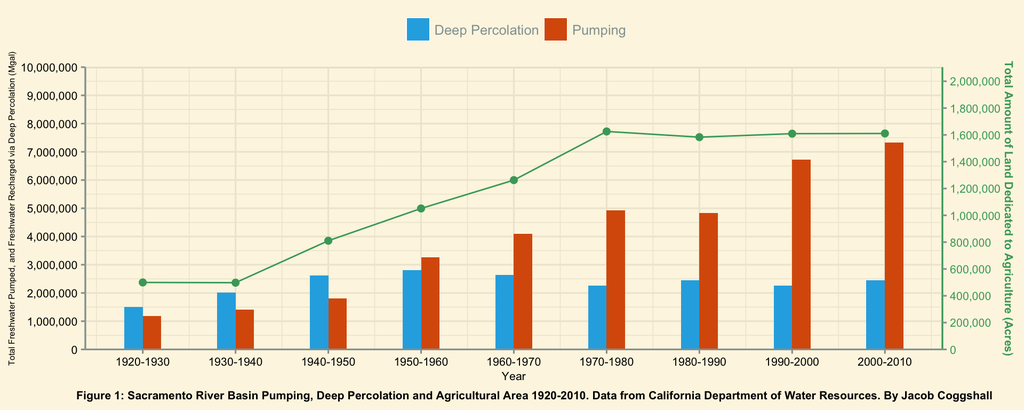

```r
ggplot() +                                                          #Calling ggplot
  theme_solarized() +                                                    #Setting the theme for the plot for visibility of data
  geom_col(data = sac_riv_water,                                    #Calling columns as the plot, and calling the correct df
           aes(x = year, y = withdrawals,                           #Setting our x and y axis
               fill = type),                                        #Filling in with our pumping and percolation data
           position = position_dodge(4),                            #Setting the distance between our bars
           width = 4)+                                              #Setting the width of our bars
  scale_fill_manual(values = c(deep_percolation = "#26AEE3",        #Setting the colors of our percolation bar
                               pumping = "#D95C09"),                #Setting the colors of our pumping bar
                    labels = c("Deep Percolation",                  #Labeling our legend titles
                            "Pumping")) +                           #Labeling our other legend title
  geom_line(data = sac_riv_basin_ag,                                #Calling the function for our trendline
            aes(x = time,                                           #Setting the x data for our trendline
                y = ag_area_ac*4.75),                               #Setting and scaling the y data for our trendline
            color = "#46A669")+                                     #Setting the color of our trendline
  geom_point(data = sac_riv_basin_ag,                               #Calling the specific points that will appear on our line
             aes(x = time,                                          #Setting the x data for our points
               y = ag_area_ac*4.75),                                #Setting and scaling the y data for our points
             color = "#46A669",                                     #Setting the color of our points
             size = 2) +                                            #Setting the size of our points
  scale_x_continuous(breaks = c(1920,                               #Setting the ticks for the data on our x axis
                                1930,
                                1940,
                                1950,
                                1960,
                                1970,
                                1980,
                                1990,
                                2000),
                     labels = c("1920-1930",                        #Labeling the ticks for the data on our x axis
                                "1930-1940",
                                "1940-1950",
                                "1950-1960",
                                "1960-1970",
                                "1970-1980",
                                "1980-1990",
                                "1990-2000",
                                "2000-2010")) +
  scale_y_continuous(breaks = scales::pretty_breaks(n = 10),       #Setting the breaks for our y axis
                     labels = scales::comma,                       #Setting what is gonna make those breaks
                     limits = c(0, 10000000),                      #Setting the limit for our y axis
                    expand = c(0, 0),                              #making our bars flush with the x axis
                    sec.axis = sec_axis( trans=~./4.75,            #Creating a second y axis, and scaling it with our trendline
                                          breaks = scales::pretty_breaks(n = 10),     #Setting the breaks for our y axis
                                          name="Total Amount of Land Dedicated to Agriculture (Acres)",  #labeling our second axis
                                          labels = scales::comma)) +    #Setting what is gonna make those breaks
  theme(axis.line.y.right = element_line(color="#46A669")) +       #Setting the color of the additional axis
  labs(x = "Year",                                                 #Setting the x axis label of our Plot
      y = "Total Freshwater Pumped, and Freshwater Recharged via Deep Percolation (Mgal)", #Setting the y axis label of our Plot
      labels = scales::comma,  #Scaling the labels with the commas
      caption = "Figure 1: Sacramento River Basin Pumping, Deep Percolation and Agricultural Area 1920-2010. Data from California Department of Water Resources. By Jacob Coggshall",      #Setting the caption of the plot
      fill = "") +
  theme(axis.text = element_text(color = "black",                 #Setting the size, color, and font of our axis titles and legend
                                  size = 8),
        axis.title.x = element_text(color = "black",
                                       size = 8),
       axis.title.y.left = element_text(color = "black",
                                   size = 6),
       axis.title.y.right = element_text(color = "#46A669",
                                         size = 8,
                                         face = "bold"),
       axis.text.y.right = element_text(color = "#46A669",
                                        size = 8),
       plot.caption = element_text(hjust = 0.15,
                                   color = "black",
                                   face = "bold",
                                   size = 8),
       legend.title = element_text(size = 6),
       legend.position = "top")                                    #Setting the position of our legend
```

#### Step #5: Organize data for our San Joaquin River Basin plot

```r
#Getting the San Joaquin River Basin Data ready for Plotting

san_j_basin <- rbind(water_reg_8,                    #Consolidating the regions into one object for the San Joaquin River Basin
                      water_reg_9,
                      water_reg_10,
                      water_reg_11,
                      water_reg_12,
                      water_reg_13)|>
  group_by(time) |>                                    #Grouping by time so we can consolidate our observations
  summarize_at(vars(1:2), sum, na.rm = TRUE) |>        #Consolidating our observations
  ungroup()                                            #Ungrouping to return our time column

san_j_1920_1930_perc <- san_j_basin|>                #Creating an object on percolation for a ten year span for our timeseries plot
    group_by(time)|>                                   #Grouping by year specifically for percolation data
  summarize_at(vars(1), sum, na.rm = TRUE)|>           #Summarizing our data so we can pivot our object to select our 10 year period
  pivot_wider(names_from = "time",                     #Pivoting or data so we can select just the years we want
              values_from = deep_percolation)|>        #Setting where we want our names and values from
  clean_names()|>                                      #Cleaning the name of our columns
  select(contains("x192"))|>                           #Selecting the columns with the first three digits of the year for our 10 years
  pivot_longer(cols = 1:99,                            #Selecting which columns to pivot
               names_to = "time",                      #Pivoting our columns os we can summarize the data
               values_to = "deep_percolation")|>       #Setting where we want our names and values to go
  distinct(deep_percolation)|>                                      #Getting rid of our time column
  summarize_at(vars(1), sum, na.rm = TRUE)             #Summarizing our column leaving a single value for 10 years of net percolation

san_j_1920_1930_pump <- san_j_basin|>                #Creating an object on pumping for a ten year span for our timeseries plot
    group_by(time)|>                                   #Grouping by year specifically for pumping data
  summarize_at(vars(2), sum, na.rm = TRUE)|>           #Summarizing our data so we can pivot our object to select our 10 year period
  pivot_wider(names_from = "time",                     #Pivoting or data so we can select just the years we want
              values_from = pumping)|>                 #Setting where we want our names and values from
  clean_names()|>                                      #Cleaning the name of our columns
  select(contains("x192"))|>                           #Selecting the columns with the first three digits of the year for our 10 years
  pivot_longer(cols = 1:99,                            #Selecting which columns to pivot
               names_to = "time",                      #Pivoting our columns os we can summarize the data
               values_to = "pumping")|>                #Setting where we want our names and values to go
  distinct(pumping)|>                                      #Getting rid of our time column
  summarize_at(vars(1), sum, na.rm = TRUE)|>           #Summarizing our column leaving a single value for 10 years of net percolation
  mutate(year = 1920)                                  #Adding in a new column for year

san_j_1920_1930 <- cbind(san_j_1920_1930_perc,       #Combining our year, percolation, pumping data for the year
                       san_j_1920_1930_pump)

  #Selecting and combing the data only from 1930-1940 year span for plotting

san_j_1930_1940_perc <- san_j_basin|>                #Creating an object on percolation for a ten year span for our timeseries plot
    group_by(time)|>                                   #Grouping by year specifically for percolation data
  summarize_at(vars(1), sum, na.rm = TRUE)|>           #Summarizing our data so we can pivot our object to select our 10 year period
  pivot_wider(names_from = "time",                     #Pivoting or data so we can select just the years we want
              values_from = deep_percolation)|>        #Setting where we want our names and values from
  clean_names()|>                                      #Cleaning the name of our columns
  select(contains("x193"))|>                           #Selecting the columns with the first three digits of the year for our 10 years
  pivot_longer(cols = 1:120,                            #Selecting which columns to pivot
               names_to = "time",                      #Pivoting our columns os we can summarize the data
               values_to = "deep_percolation")|>       #Setting where we want our names and values to go
  distinct(deep_percolation)|>                                      #Getting rid of our time column
  summarize_at(vars(1), sum, na.rm = TRUE)             #Summarizing our column leaving a single value for 10 years of net percolation

san_j_1930_1940_pump <- san_j_basin|>                #Creating an object on pumping for a ten year span for our timeseries plot
    group_by(time)|>                                   #Grouping by year specifically for pumping data
  summarize_at(vars(2), sum, na.rm = TRUE)|>           #Summarizing our data so we can pivot our object to select our 10 year period
  pivot_wider(names_from = "time",                     #Pivoting or data so we can select just the years we want
              values_from = pumping)|>                 #Setting where we want our names and values from
  clean_names()|>                                      #Cleaning the name of our columns
  select(contains("x193"))|>                           #Selecting the columns with the first three digits of the year for our 10 years
  pivot_longer(cols = 1:120,                            #Selecting which columns to pivot
               names_to = "time",                      #Pivoting our columns os we can summarize the data
               values_to = "pumping")|>                #Setting where we want our names and values to go
  distinct(pumping)|>                                      #Getting rid of our time column
  summarize_at(vars(1), sum, na.rm = TRUE)|>           #Summarizing our column leaving a single value for 10 years of net percolation
  mutate(year = 1930)                                  #Adding in a new column for year
```

```r
san_j_1930_1940 <- cbind(san_j_1930_1940_perc,       #Combining our year, percolation, pumping data for the year
                       san_j_1930_1940_pump)

#Selecting and combing the data only from 1940-1950 year span for plotting

san_j_1940_1950_perc <- san_j_basin|>                #Creating an object on percolation for a ten year span for our timeseries plot
    group_by(time)|>                                   #Grouping by year specifically for percolation data
  summarize_at(vars(1), sum, na.rm = TRUE)|>           #Summarizing our data so we can pivot our object to select our 10 year period
  pivot_wider(names_from = "time",                     #Pivoting or data so we can select just the years we want
              values_from = deep_percolation)|>        #Setting where we want our names and values from
  clean_names()|>                                      #Cleaning the name of our columns
  select(contains("x194"))|>                           #Selecting the columns with the first three digits of the year for our 10 years
  pivot_longer(cols = 1:120,                            #Selecting which columns to pivot
               names_to = "time",                      #Pivoting our columns os we can summarize the data
               values_to = "deep_percolation")|>       #Setting where we want our names and values to go
  distinct(deep_percolation)|>                                      #Getting rid of our time column
  summarize_at(vars(1), sum, na.rm = TRUE)             #Summarizing our column leaving a single value for 10 years of net percolation

san_j_1940_1950_pump <- san_j_basin|>                #Creating an object on pumping for a ten year span for our timeseries plot
    group_by(time)|>                                   #Grouping by year specifically for pumping data
  summarize_at(vars(2), sum, na.rm = TRUE)|>           #Summarizing our data so we can pivot our object to select our 10 year period
  pivot_wider(names_from = "time",                     #Pivoting or data so we can select just the years we want
              values_from = pumping)|>                 #Setting where we want our names and values from
  clean_names()|>                                      #Cleaning the name of our columns
  select(contains("x194"))|>                           #Selecting the columns with the first three digits of the year for our 10 years
  pivot_longer(cols = 1:120,                            #Selecting which columns to pivot
               names_to = "time",                      #Pivoting our columns os we can summarize the data
               values_to = "pumping")|>                #Setting where we want our names and values to go
  distinct(pumping)|>                                      #Getting rid of our time column
  summarize_at(vars(1), sum, na.rm = TRUE)|>           #Summarizing our column leaving a single value for 10 years of net percolation
  mutate(year = 1940)                                  #Adding in a new column for year

san_j_1940_1950 <- cbind(san_j_1940_1950_perc,       #Combining our year, percolation, pumping data for the year
                       san_j_1940_1950_pump)

#Selecting and combing the data only from 1950-1960 year span for plotting

san_j_1950_1960_perc <- san_j_basin|>                #Creating an object on percolation for a ten year span for our timeseries plot
    group_by(time)|>                                   #Grouping by year specifically for percolation data
  summarize_at(vars(1), sum, na.rm = TRUE)|>           #Summarizing our data so we can pivot our object to select our 10 year period
  pivot_wider(names_from = "time",                     #Pivoting or data so we can select just the years we want
              values_from = deep_percolation)|>        #Setting where we want our names and values from
  clean_names()|>                                      #Cleaning the name of our columns
  select(contains("x195"))|>                           #Selecting the columns with the first three digits of the year for our 10 years
  pivot_longer(cols = 1:120,                            #Selecting which columns to pivot
               names_to = "time",                      #Pivoting our columns os we can summarize the data
               values_to = "deep_percolation")|>       #Setting where we want our names and values to go
  distinct(deep_percolation)|>                                      #Getting rid of our time column
  summarize_at(vars(1), sum, na.rm = TRUE)             #Summarizing our column leaving a single value for 10 years of net percolation

san_j_1950_1960_pump <- san_j_basin|>                #Creating an object on pumping for a ten year span for our timeseries plot
    group_by(time)|>                                   #Grouping by year specifically for pumping data
  summarize_at(vars(2), sum, na.rm = TRUE)|>           #Summarizing our data so we can pivot our object to select our 10 year period
  pivot_wider(names_from = "time",                     #Pivoting or data so we can select just the years we want
              values_from = pumping)|>                 #Setting where we want our names and values from
  clean_names()|>                                      #Cleaning the name of our columns
  select(contains("x195"))|>                           #Selecting the columns with the first three digits of the year for our 10 years
  pivot_longer(cols = 1:120,                            #Selecting which columns to pivot
               names_to = "time",                      #Pivoting our columns os we can summarize the data
               values_to = "pumping")|>                #Setting where we want our names and values to go
  distinct(pumping)|>                                      #Getting rid of our time column
  summarize_at(vars(1), sum, na.rm = TRUE)|>           #Summarizing our column leaving a single value for 10 years of net percolation
  mutate(year = 1950)                                  #Adding in a new column for year
```

```r
san_j_1950_1960 <- cbind(san_j_1950_1960_perc,       #Combining our year, percolation, pumping data for the year
                       san_j_1950_1960_pump)


#Selecting and combing the data only from 1960-1970 year span for plotting

san_j_1960_1970_perc <- san_j_basin|>                #Creating an object on percolation for a ten year span for our timeseries plot
    group_by(time)|>                                   #Grouping by year specifically for percolation data
  summarize_at(vars(1), sum, na.rm = TRUE)|>           #Summarizing our data so we can pivot our object to select our 10 year period
  pivot_wider(names_from = "time",                     #Pivoting or data so we can select just the years we want
              values_from = deep_percolation)|>        #Setting where we want our names and values from
  clean_names()|>                                      #Cleaning the name of our columns
  select(contains("x196"))|>                           #Selecting the columns with the first three digits of the year for our 10 years
  pivot_longer(cols = 1:120,                            #Selecting which columns to pivot
               names_to = "time",                      #Pivoting our columns os we can summarize the data
               values_to = "deep_percolation")|>       #Setting where we want our names and values to go
  distinct(deep_percolation)|>                                      #Getting rid of our time column
  summarize_at(vars(1), sum, na.rm = TRUE)             #Summarizing our column leaving a single value for 10 years of net percolation

san_j_1960_1970_pump <- san_j_basin|>                #Creating an object on pumping for a ten year span for our timeseries plot
    group_by(time)|>                                   #Grouping by year specifically for pumping data
  summarize_at(vars(2), sum, na.rm = TRUE)|>           #Summarizing our data so we can pivot our object to select our 10 year period
  pivot_wider(names_from = "time",                     #Pivoting or data so we can select just the years we want
              values_from = pumping)|>                 #Setting where we want our names and values from
  clean_names()|>                                      #Cleaning the name of our columns
  select(contains("x196"))|>                           #Selecting the columns with the first three digits of the year for our 10 years
  pivot_longer(cols = 1:120,                            #Selecting which columns to pivot
               names_to = "time",                      #Pivoting our columns os we can summarize the data
               values_to = "pumping")|>                #Setting where we want our names and values to go
  distinct(pumping)|>                                      #Getting rid of our time column
  summarize_at(vars(1), sum, na.rm = TRUE)|>           #Summarizing our column leaving a single value for 10 years of net percolation
  mutate(year = 1960)                                  #Adding in a new column for year

san_j_1960_1970 <- cbind(san_j_1960_1970_perc,       #Combining our year, percolation, pumping data for the year
                       san_j_1960_1970_pump)

#Selecting and combing the data only from 1970-1980 year span for plotting

san_j_1970_1980_perc <- san_j_basin|>                #Creating an object on percolation for a ten year span for our timeseries plot
    group_by(time)|>                                   #Grouping by year specifically for percolation data
  summarize_at(vars(1), sum, na.rm = TRUE)|>           #Summarizing our data so we can pivot our object to select our 10 year period
  pivot_wider(names_from = "time",                     #Pivoting or data so we can select just the years we want
              values_from = deep_percolation)|>        #Setting where we want our names and values from
  clean_names()|>                                      #Cleaning the name of our columns
  select(contains("x197"))|>                           #Selecting the columns with the first three digits of the year for our 10 years
  pivot_longer(cols = 1:120,                            #Selecting which columns to pivot
               names_to = "time",                      #Pivoting our columns os we can summarize the data
               values_to = "deep_percolation")|>       #Setting where we want our names and values to go
  distinct(deep_percolation)|>                                      #Getting rid of our time column
  summarize_at(vars(1), sum, na.rm = TRUE)             #Summarizing our column leaving a single value for 10 years of net percolation

san_j_1970_1980_pump <- san_j_basin|>                #Creating an object on pumping for a ten year span for our timeseries plot
    group_by(time)|>                                   #Grouping by year specifically for pumping data
  summarize_at(vars(2), sum, na.rm = TRUE)|>           #Summarizing our data so we can pivot our object to select our 10 year period
  pivot_wider(names_from = "time",                     #Pivoting or data so we can select just the years we want
              values_from = pumping)|>                 #Setting where we want our names and values from
  clean_names()|>                                      #Cleaning the name of our columns
  select(contains("x197"))|>                           #Selecting the columns with the first three digits of the year for our 10 years
  pivot_longer(cols = 1:120,                            #Selecting which columns to pivot
               names_to = "time",                      #Pivoting our columns os we can summarize the data
               values_to = "pumping")|>                #Setting where we want our names and values to go
  distinct(pumping)|>                                      #Getting rid of our time column
  summarize_at(vars(1), sum, na.rm = TRUE)|>           #Summarizing our column leaving a single value for 10 years of net percolation
  mutate(year = 1970)                                  #Adding in a new column for year
```

```r
san_j_1970_1980 <- cbind(san_j_1970_1980_perc,       #Combining our year, percolation, pumping data for the year
                       san_j_1970_1980_pump)

#Selecting and combing the data only from 1980-1990 year span for plotting

san_j_1980_1990_perc <- san_j_basin|>                #Creating an object on percolation for a ten year span for our timeseries plot
    group_by(time)|>                                   #Grouping by year specifically for percolation data
  summarize_at(vars(1), sum, na.rm = TRUE)|>           #Summarizing our data so we can pivot our object to select our 10 year period
  pivot_wider(names_from = "time",                     #Pivoting or data so we can select just the years we want
              values_from = deep_percolation)|>        #Setting where we want our names and values from
  clean_names()|>                                      #Cleaning the name of our columns
  select(contains("x198"))|>                           #Selecting the columns with the first three digits of the year for our 10 years
  pivot_longer(cols = 1:120,                            #Selecting which columns to pivot
               names_to = "time",                      #Pivoting our columns os we can summarize the data
               values_to = "deep_percolation")|>       #Setting where we want our names and values to go
  distinct(deep_percolation)|>                                      #Getting rid of our time column
  summarize_at(vars(1), sum, na.rm = TRUE)             #Summarizing our column leaving a single value for 10 years of net percolation

san_j_1980_1990_pump <- san_j_basin|>                #Creating an object on pumping for a ten year span for our timeseries plot
    group_by(time)|>                                   #Grouping by year specifically for pumping data
  summarize_at(vars(2), sum, na.rm = TRUE)|>           #Summarizing our data so we can pivot our object to select our 10 year period
  pivot_wider(names_from = "time",                     #Pivoting or data so we can select just the years we want
              values_from = pumping)|>                 #Setting where we want our names and values from
  clean_names()|>                                      #Cleaning the name of our columns
  select(contains("x198"))|>                           #Selecting the columns with the first three digits of the year for our 10 years
  pivot_longer(cols = 1:120,                            #Selecting which columns to pivot
               names_to = "time",                      #Pivoting our columns os we can summarize the data
               values_to = "pumping")|>                #Setting where we want our names and values to go
  distinct(pumping)|>                                      #Getting rid of our time column
  summarize_at(vars(1), sum, na.rm = TRUE)|>           #Summarizing our column leaving a single value for 10 years of net percolation
  mutate(year = 1980)                                  #Adding in a new column for year

san_j_1980_1990 <- cbind(san_j_1980_1990_perc,       #Combining our year, percolation, pumping data for the year
                       san_j_1980_1990_pump)

#Selecting and combing the data only from 1990-2000 year span for plotting

san_j_1990_2000_perc <- san_j_basin|>                #Creating an object on percolation for a ten year span for our timeseries plot
    group_by(time)|>                                   #Grouping by year specifically for percolation data
  summarize_at(vars(1), sum, na.rm = TRUE)|>           #Summarizing our data so we can pivot our object to select our 10 year period
  pivot_wider(names_from = "time",                     #Pivoting or data so we can select just the years we want
              values_from = deep_percolation)|>        #Setting where we want our names and values from
  clean_names()|>                                      #Cleaning the name of our columns
  select(contains("x199"))|>                           #Selecting the columns with the first three digits of the year for our 10 years
  pivot_longer(cols = 1:120,                            #Selecting which columns to pivot
               names_to = "time",                      #Pivoting our columns os we can summarize the data
               values_to = "deep_percolation")|>       #Setting where we want our names and values to go
  distinct(deep_percolation)|>                                      #Getting rid of our time column
  summarize_at(vars(1), sum, na.rm = TRUE)             #Summarizing our column leaving a single value for 10 years of net percolation

san_j_1990_2000_pump <- san_j_basin|>                #Creating an object on pumping for a ten year span for our timeseries plot
    group_by(time)|>                                   #Grouping by year specifically for pumping data
  summarize_at(vars(2), sum, na.rm = TRUE)|>           #Summarizing our data so we can pivot our object to select our 10 year period
  pivot_wider(names_from = "time",                     #Pivoting or data so we can select just the years we want
              values_from = pumping)|>                 #Setting where we want our names and values from
  clean_names()|>                                      #Cleaning the name of our columns
  select(contains("x199"))|>                           #Selecting the columns with the first three digits of the year for our 10 years
  pivot_longer(cols = 1:120,                            #Selecting which columns to pivot
               names_to = "time",                      #Pivoting our columns os we can summarize the data
               values_to = "pumping")|>                #Setting where we want our names and values to go
  distinct(pumping)|>                                      #Getting rid of our time column
  summarize_at(vars(1), sum, na.rm = TRUE)|>           #Summarizing our column leaving a single value for 10 years of net percolation
  mutate(year = 1990)                                  #Adding in a new column for year
```

```r
san_j_1990_2000 <- cbind(san_j_1990_2000_perc,       #Combining our year, percolation, pumping data for the year
                       san_j_1990_2000_pump)


 #Selecting and combing the data only from 2000-2010 year span for plotting

san_j_2000_2010_perc <- san_j_basin|>                #Creating an object on percolation for a ten year span for our timeseries plot
    group_by(time)|>                                   #Grouping by year specifically for percolation data
  summarize_at(vars(1), sum, na.rm = TRUE)|>           #Summarizing our data so we can pivot our object to select our 10 year period
  pivot_wider(names_from = "time",                     #Pivoting or data so we can select just the years we want
              values_from = deep_percolation)|>        #Setting where we want our names and values from
  clean_names()|>                                      #Cleaning the name of our columns
  select(contains("x200"))|>                           #Selecting the columns with the first three digits of the year for our 10 years
  pivot_longer(cols = 1:117,                            #Selecting which columns to pivot
               names_to = "time",                      #Pivoting our columns os we can summarize the data
               values_to = "deep_percolation")|>       #Setting where we want our names and values to go
  distinct(deep_percolation)|>                                      #Getting rid of our time column
  summarize_at(vars(1), sum, na.rm = TRUE)             #Summarizing our column leaving a single value for 10 years of net percolation

san_j_2000_2010_pump <- san_j_basin|>                #Creating an object on pumping for a ten year span for our timeseries plot
    group_by(time)|>                                   #Grouping by year specifically for pumping data
  summarize_at(vars(2), sum, na.rm = TRUE)|>           #Summarizing our data so we can pivot our object to select our 10 year period
  pivot_wider(names_from = "time",                     #Pivoting or data so we can select just the years we want
              values_from = pumping)|>                 #Setting where we want our names and values from
  clean_names()|>                                      #Cleaning the name of our columns
  select(contains("x200"))|>                           #Selecting the columns with the first three digits of the year for our 10 years
  pivot_longer(cols = 1:117,                            #Selecting which columns to pivot
               names_to = "time",                      #Pivoting our columns os we can summarize the data
               values_to = "pumping")|>                #Setting where we want our names and values to go
  distinct(pumping)|>                                      #Getting rid of our time column
  summarize_at(vars(1), sum, na.rm = TRUE)|>           #Summarizing our column leaving a single value for 10 years of net percolation
  mutate(year = 2000)                                  #Adding in a new column for year

san_j_2000_2010 <- cbind(san_j_2000_2010_perc,       #Combining our year, percolation, pumping data for the year
                       san_j_2000_2010_pump)

san_j_water <- rbind(san_j_1920_1930,                #Combining all these 10 year periods into one object
                   san_j_1930_1940,
                   san_j_1940_1950,
                   san_j_1950_1960,
                   san_j_1960_1970,
                   san_j_1970_1980,
                   san_j_1980_1990,
                   san_j_1990_2000,
                   san_j_2000_2010)|>
                pivot_longer(cols = 1:2,              #Pivoting our data so we can use the fill sector function to put our bars in
                names_to = "type",                    #Sending our names to type
                values_to = "withdrawals")            #Sending our value to withdrawals

  san_j_water$withdrawals <- 0.32585*(san_j_water$withdrawals)  #Converting our units from Acre Feet to Mgal


#Consolidating the regions ag data into one object for the san_j Basin

san_j_basin_ag <- rbind(ag_reg_8,                   #Combining our data on agriculture area for these regions
                      ag_reg_9,
                      ag_reg_10,
                      ag_reg_11,
                      ag_reg_12,
                      ag_reg_13)|>
  group_by(time) |>                                   #Grouping our objects by time so we can consolidate the number of observations
  summarize_at(vars(1), sum, na.rm = TRUE) |>         #Combining the acres of the multiple regions into the greater basin
  ungroup()|>                                         #Ungrouping our data
 pivot_wider(names_from = time,                       #Pivoting our data so we can select our specific date four our trendline
             values_from = ag_area_ac)|>              #Selecting our values from agriculture area, and names from time
  select(contains("09-30"))|>                         #Selecting the observation from 9/30 each year for agricultural area
           select(contains("1929"),                   #Selecting the observation from this day for each of the 10 year periods
                           contains("1939"),
                           contains("1949"),
                           contains("1959"),
                           contains("1969"),
                           contains("1979"),
                           contains("1989"),
                           contains("1999"),
                           contains("2009"))|>
  clean_names()|>                                     #Cleaing the names of our data
  select("1920" = x1929_09_30,                        #Changing the names of our columns
         "1930" = x1939_09_30,
         "1940" = x1949_09_30,
         "1950" = x1959_09_30,
         "1960" = x1969_09_30,
         "1970" = x1979_09_30,
         "1980" = x1989_09_30,
         "1990" = x1999_09_30,
         "2000" = x2009_09_30)|>
  pivot_longer(cols = 1:9,                             #Pivoting our data so we can use it for our trendline
               names_to = "time",
               values_to = "ag_area_ac")|>
  mutate_at(1, as.numeric, na.rm = TRUE)
```

#### Step #6: San Joaquin River Basin plot

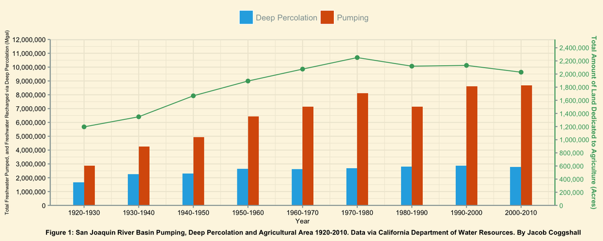

```r
ggplot() +                                                          #Calling ggplot
  theme_solarized() +                                                    #Setting the theme for the plot for visibility of data
  geom_col(data = san_j_water,                                    #Calling columns as the plot, and calling the correct df
           aes(x = year, y = withdrawals,                           #Setting our x and y axis
               fill = type),                                        #Filling in with our pumping and percolation data
           position = position_dodge(4),                            #Setting the distance between our bars
           width = 4)+                                              #Setting the width of our bars
  scale_fill_manual(values = c(deep_percolation = "#26AEE3",        #Setting the colors of our percolation bar
                               pumping = "#D95C09"),                #Setting the colors of our pumping bar
                    labels = c("Deep Percolation",                  #Labeling our legend titles
                            "Pumping")) +                           #Labeling our other legend title
  geom_line(data = san_j_basin_ag,                                #Calling the function for our trendline
            aes(x = time,                                           #Setting the x data for our trendline
                y = ag_area_ac*4.75),                               #Setting and scaling the y data for our trendline
            color = "#46A669")+                                     #Setting the color of our trendline
  geom_point(data = san_j_basin_ag,                               #Calling the specific points that will appear on our line
             aes(x = time,                                          #Setting the x data for our points
               y = ag_area_ac*4.75),                                #Setting and scaling the y data for our points
             color = "#46A669",                                     #Setting the color of our points
             size = 2) +                                            #Setting the size of our points
  scale_x_continuous(breaks = c(1920,                               #Setting the ticks for the data on our x axis
                                1930,
                                1940,
                                1950,
                                1960,
                                1970,
                                1980,
                                1990,
                                2000),
                     labels = c("1920-1930",                        #Labeling the ticks for the data on our x axis
                                "1930-1940",
                                "1940-1950",
                                "1950-1960",
                                "1960-1970",
                                "1970-1980",
                                "1980-1990",
                                "1990-2000",
                                "2000-2010")) +
  scale_y_continuous(breaks = scales::pretty_breaks(n = 10),       #Setting the breaks for our y axis
                     labels = scales::comma,                       #Setting what is gonna make those breaks
                     limits = c(0, 12000000),                      #Setting the limit for our y axis
                    expand = c(0, 0),                              #making our bars flush with the x axis
                    sec.axis = sec_axis( trans=~./4.75,            #Creating a second y axis, and scaling it with our trendline
                                          breaks = scales::pretty_breaks(n = 10),     #Setting the breaks for our y axis
                                          name="Total Amount of Land Dedicated to Agriculture (Acres)",  #labeling our second axis
                                          labels = scales::comma)) +    #Setting what is gonna make those breaks
  theme(axis.line.y.right = element_line(color="#46A669")) +       #Setting the color of the additional axis
  labs(x = "Year",                                                 #Setting the x axis label of our Plot
      y = "Total Freshwater Pumped, and Freshwater Recharged via Deep Percolation (Mgal)", #Setting the y axis label of our Plot
      labels = scales::comma,  #Scaling the labels with the commas
      caption = "Figure 1: San Joaquin River Basin Pumping, Deep Percolation and Agricultural Area 1920-2010. Data via California Department of Water Resources. By Jacob Coggshall",      #Setting the caption of the plot
      fill = "") +
  theme(axis.text = element_text(color = "black",                 #Setting the size, color, and font of our axis titles and legend
                                  size = 8),
        axis.title.x = element_text(color = "black",
                                       size = 8),
       axis.title.y.left = element_text(color = "black",
                                   size = 6),
       axis.title.y.right = element_text(color = "#46A669",
                                         size = 8,
                                         face = "bold"),
       axis.text.y.right = element_text(color = "#46A669",
                                        size = 8),
       plot.caption = element_text(hjust = 0.15,
                                   color = "black",
                                   face = "bold",
                                   size = 8),
       legend.title = element_text(size = 6),
       legend.position = "top")                                    #Setting the position of our legend
```

#### Step #7: Organize data for our Tulare Basin plot

```r
#Getting the Tulare Basin Data ready for Plotting

tulare_basin <- rbind(water_reg_14,                    #Consolidating the regions into one object for the Tulare Basin
                      water_reg_15,
                      water_reg_16,
                      water_reg_17,
                      water_reg_18,
                      water_reg_19,
                      water_reg_20,
                      water_reg_21)|>
  group_by(time) |>                                    #Grouping by time so we can consolidate our observations
  summarize_at(vars(1:2), sum, na.rm = TRUE) |>        #Consolidating our observations
  ungroup()                                            #Ungrouping to return our time column

tulare_1920_1930_perc <- tulare_basin|>                #Creating an object on percolation for a ten year span for our timeseries plot
    group_by(time)|>                                   #Grouping by year specifically for percolation data
  summarize_at(vars(1), sum, na.rm = TRUE)|>           #Summarizing our data so we can pivot our object to select our 10 year period
  pivot_wider(names_from = "time",                     #Pivoting or data so we can select just the years we want
              values_from = deep_percolation)|>        #Setting where we want our names and values from
  clean_names()|>                                      #Cleaning the name of our columns
  select(contains("x192"))|>                           #Selecting the columns with the first three digits of the year for our 10 years
  pivot_longer(cols = 1:99,                            #Selecting which columns to pivot
               names_to = "time",                      #Pivoting our columns os we can summarize the data
               values_to = "deep_percolation")|>       #Setting where we want our names and values to go
  distinct(deep_percolation)|>                                      #Getting rid of our time column
  summarize_at(vars(1), sum, na.rm = TRUE)             #Summarizing our column leaving a single value for 10 years of net percolation

tulare_1920_1930_pump <- tulare_basin|>                #Creating an object on pumping for a ten year span for our timeseries plot
    group_by(time)|>                                   #Grouping by year specifically for pumping data
  summarize_at(vars(2), sum, na.rm = TRUE)|>           #Summarizing our data so we can pivot our object to select our 10 year period
  pivot_wider(names_from = "time",                     #Pivoting or data so we can select just the years we want
              values_from = pumping)|>                 #Setting where we want our names and values from
  clean_names()|>                                      #Cleaning the name of our columns
  select(contains("x192"))|>                           #Selecting the columns with the first three digits of the year for our 10 years
  pivot_longer(cols = 1:99,                            #Selecting which columns to pivot
               names_to = "time",                      #Pivoting our columns os we can summarize the data
               values_to = "pumping")|>                #Setting where we want our names and values to go
  distinct(pumping)|>                                      #Getting rid of our time column
  summarize_at(vars(1), sum, na.rm = TRUE)|>           #Summarizing our column leaving a single value for 10 years of net percolation
  mutate(year = 1920)                                  #Adding in a new column for year

tulare_1920_1930 <- cbind(tulare_1920_1930_perc,       #Combining our year, percolation, pumping data for the year
                       tulare_1920_1930_pump)

  #Selecting and combing the data only from 1930-1940 year span for plotting

tulare_1930_1940_perc <- tulare_basin|>                #Creating an object on percolation for a ten year span for our timeseries plot
    group_by(time)|>                                   #Grouping by year specifically for percolation data
  summarize_at(vars(1), sum, na.rm = TRUE)|>           #Summarizing our data so we can pivot our object to select our 10 year period
  pivot_wider(names_from = "time",                     #Pivoting or data so we can select just the years we want
              values_from = deep_percolation)|>        #Setting where we want our names and values from
  clean_names()|>                                      #Cleaning the name of our columns
  select(contains("x193"))|>                           #Selecting the columns with the first three digits of the year for our 10 years
  pivot_longer(cols = 1:120,                            #Selecting which columns to pivot
               names_to = "time",                      #Pivoting our columns os we can summarize the data
               values_to = "deep_percolation")|>       #Setting where we want our names and values to go
  distinct(deep_percolation)|>                                      #Getting rid of our time column
  summarize_at(vars(1), sum, na.rm = TRUE)             #Summarizing our column leaving a single value for 10 years of net percolation

tulare_1930_1940_pump <- tulare_basin|>                #Creating an object on pumping for a ten year span for our timeseries plot
    group_by(time)|>                                   #Grouping by year specifically for pumping data
  summarize_at(vars(2), sum, na.rm = TRUE)|>           #Summarizing our data so we can pivot our object to select our 10 year period
  pivot_wider(names_from = "time",                     #Pivoting or data so we can select just the years we want
              values_from = pumping)|>                 #Setting where we want our names and values from
  clean_names()|>                                      #Cleaning the name of our columns
  select(contains("x193"))|>                           #Selecting the columns with the first three digits of the year for our 10 years
  pivot_longer(cols = 1:120,                            #Selecting which columns to pivot
               names_to = "time",                      #Pivoting our columns os we can summarize the data
               values_to = "pumping")|>                #Setting where we want our names and values to go
  distinct(pumping)|>                                      #Getting rid of our time column
  summarize_at(vars(1), sum, na.rm = TRUE)|>           #Summarizing our column leaving a single value for 10 years of net percolation
  mutate(year = 1930)                                  #Adding in a new column for year
```

```r
tulare_1930_1940 <- cbind(tulare_1930_1940_perc,       #Combining our year, percolation, pumping data for the year
                       tulare_1930_1940_pump)

#Selecting and combing the data only from 1940-1950 year span for plotting

tulare_1940_1950_perc <- tulare_basin|>                #Creating an object on percolation for a ten year span for our timeseries plot
    group_by(time)|>                                   #Grouping by year specifically for percolation data
  summarize_at(vars(1), sum, na.rm = TRUE)|>           #Summarizing our data so we can pivot our object to select our 10 year period
  pivot_wider(names_from = "time",                     #Pivoting or data so we can select just the years we want
              values_from = deep_percolation)|>        #Setting where we want our names and values from
  clean_names()|>                                      #Cleaning the name of our columns
  select(contains("x194"))|>                           #Selecting the columns with the first three digits of the year for our 10 years
  pivot_longer(cols = 1:120,                            #Selecting which columns to pivot
               names_to = "time",                      #Pivoting our columns os we can summarize the data
               values_to = "deep_percolation")|>       #Setting where we want our names and values to go
  distinct(deep_percolation)|>                                      #Getting rid of our time column
  summarize_at(vars(1), sum, na.rm = TRUE)             #Summarizing our column leaving a single value for 10 years of net percolation

tulare_1940_1950_pump <- tulare_basin|>                #Creating an object on pumping for a ten year span for our timeseries plot
    group_by(time)|>                                   #Grouping by year specifically for pumping data
  summarize_at(vars(2), sum, na.rm = TRUE)|>           #Summarizing our data so we can pivot our object to select our 10 year period
  pivot_wider(names_from = "time",                     #Pivoting or data so we can select just the years we want
              values_from = pumping)|>                 #Setting where we want our names and values from
  clean_names()|>                                      #Cleaning the name of our columns
  select(contains("x194"))|>                           #Selecting the columns with the first three digits of the year for our 10 years
  pivot_longer(cols = 1:120,                            #Selecting which columns to pivot
               names_to = "time",                      #Pivoting our columns os we can summarize the data
               values_to = "pumping")|>                #Setting where we want our names and values to go
  distinct(pumping)|>                                      #Getting rid of our time column
  summarize_at(vars(1), sum, na.rm = TRUE)|>           #Summarizing our column leaving a single value for 10 years of net percolation
  mutate(year = 1940)                                  #Adding in a new column for year

tulare_1940_1950 <- cbind(tulare_1940_1950_perc,       #Combining our year, percolation, pumping data for the year
                       tulare_1940_1950_pump)

#Selecting and combing the data only from 1950-1960 year span for plotting

tulare_1950_1960_perc <- tulare_basin|>                #Creating an object on percolation for a ten year span for our timeseries plot
    group_by(time)|>                                   #Grouping by year specifically for percolation data
  summarize_at(vars(1), sum, na.rm = TRUE)|>           #Summarizing our data so we can pivot our object to select our 10 year period
  pivot_wider(names_from = "time",                     #Pivoting or data so we can select just the years we want
              values_from = deep_percolation)|>        #Setting where we want our names and values from
  clean_names()|>                                      #Cleaning the name of our columns
  select(contains("x195"))|>                           #Selecting the columns with the first three digits of the year for our 10 years
  pivot_longer(cols = 1:120,                            #Selecting which columns to pivot
               names_to = "time",                      #Pivoting our columns os we can summarize the data
               values_to = "deep_percolation")|>       #Setting where we want our names and values to go
  distinct(deep_percolation)|>                                      #Getting rid of our time column
  summarize_at(vars(1), sum, na.rm = TRUE)             #Summarizing our column leaving a single value for 10 years of net percolation

tulare_1950_1960_pump <- tulare_basin|>                #Creating an object on pumping for a ten year span for our timeseries plot
    group_by(time)|>                                   #Grouping by year specifically for pumping data
  summarize_at(vars(2), sum, na.rm = TRUE)|>           #Summarizing our data so we can pivot our object to select our 10 year period
  pivot_wider(names_from = "time",                     #Pivoting or data so we can select just the years we want
              values_from = pumping)|>                 #Setting where we want our names and values from
  clean_names()|>                                      #Cleaning the name of our columns
  select(contains("x195"))|>                           #Selecting the columns with the first three digits of the year for our 10 years
  pivot_longer(cols = 1:120,                            #Selecting which columns to pivot
               names_to = "time",                      #Pivoting our columns os we can summarize the data
               values_to = "pumping")|>                #Setting where we want our names and values to go
  distinct(pumping)|>                                      #Getting rid of our time column
  summarize_at(vars(1), sum, na.rm = TRUE)|>           #Summarizing our column leaving a single value for 10 years of net percolation
  mutate(year = 1950)                                  #Adding in a new column for year
```

```r
tulare_1950_1960 <- cbind(tulare_1950_1960_perc,       #Combining our year, percolation, pumping data for the year
                       tulare_1950_1960_pump)


#Selecting and combing the data only from 1960-1970 year span for plotting

tulare_1960_1970_perc <- tulare_basin|>                #Creating an object on percolation for a ten year span for our timeseries plot
    group_by(time)|>                                   #Grouping by year specifically for percolation data
  summarize_at(vars(1), sum, na.rm = TRUE)|>           #Summarizing our data so we can pivot our object to select our 10 year period
  pivot_wider(names_from = "time",                     #Pivoting or data so we can select just the years we want
              values_from = deep_percolation)|>        #Setting where we want our names and values from
  clean_names()|>                                      #Cleaning the name of our columns
  select(contains("x196"))|>                           #Selecting the columns with the first three digits of the year for our 10 years
  pivot_longer(cols = 1:120,                            #Selecting which columns to pivot
               names_to = "time",                      #Pivoting our columns os we can summarize the data
               values_to = "deep_percolation")|>       #Setting where we want our names and values to go
  distinct(deep_percolation)|>                                      #Getting rid of our time column
  summarize_at(vars(1), sum, na.rm = TRUE)             #Summarizing our column leaving a single value for 10 years of net percolation

tulare_1960_1970_pump <- tulare_basin|>                #Creating an object on pumping for a ten year span for our timeseries plot
    group_by(time)|>                                   #Grouping by year specifically for pumping data
  summarize_at(vars(2), sum, na.rm = TRUE)|>           #Summarizing our data so we can pivot our object to select our 10 year period
  pivot_wider(names_from = "time",                     #Pivoting or data so we can select just the years we want
              values_from = pumping)|>                 #Setting where we want our names and values from
  clean_names()|>                                      #Cleaning the name of our columns
  select(contains("x196"))|>                           #Selecting the columns with the first three digits of the year for our 10 years
  pivot_longer(cols = 1:120,                            #Selecting which columns to pivot
               names_to = "time",                      #Pivoting our columns os we can summarize the data
               values_to = "pumping")|>                #Setting where we want our names and values to go
  distinct(pumping)|>                                      #Getting rid of our time column
  summarize_at(vars(1), sum, na.rm = TRUE)|>           #Summarizing our column leaving a single value for 10 years of net percolation
  mutate(year = 1960)                                  #Adding in a new column for year

tulare_1960_1970 <- cbind(tulare_1960_1970_perc,       #Combining our year, percolation, pumping data for the year
                       tulare_1960_1970_pump)

#Selecting and combing the data only from 1970-1980 year span for plotting

tulare_1970_1980_perc <- tulare_basin|>                #Creating an object on percolation for a ten year span for our timeseries plot
    group_by(time)|>                                   #Grouping by year specifically for percolation data
  summarize_at(vars(1), sum, na.rm = TRUE)|>           #Summarizing our data so we can pivot our object to select our 10 year period
  pivot_wider(names_from = "time",                     #Pivoting or data so we can select just the years we want
              values_from = deep_percolation)|>        #Setting where we want our names and values from
  clean_names()|>                                      #Cleaning the name of our columns
  select(contains("x197"))|>                           #Selecting the columns with the first three digits of the year for our 10 years
  pivot_longer(cols = 1:120,                            #Selecting which columns to pivot
               names_to = "time",                      #Pivoting our columns os we can summarize the data
               values_to = "deep_percolation")|>       #Setting where we want our names and values to go
  distinct(deep_percolation)|>                                      #Getting rid of our time column
  summarize_at(vars(1), sum, na.rm = TRUE)             #Summarizing our column leaving a single value for 10 years of net percolation

tulare_1970_1980_pump <- tulare_basin|>                #Creating an object on pumping for a ten year span for our timeseries plot
    group_by(time)|>                                   #Grouping by year specifically for pumping data
  summarize_at(vars(2), sum, na.rm = TRUE)|>           #Summarizing our data so we can pivot our object to select our 10 year period
  pivot_wider(names_from = "time",                     #Pivoting or data so we can select just the years we want
              values_from = pumping)|>                 #Setting where we want our names and values from
  clean_names()|>                                      #Cleaning the name of our columns
  select(contains("x197"))|>                           #Selecting the columns with the first three digits of the year for our 10 years
  pivot_longer(cols = 1:120,                            #Selecting which columns to pivot
               names_to = "time",                      #Pivoting our columns os we can summarize the data
               values_to = "pumping")|>                #Setting where we want our names and values to go
 distinct(pumping)|>                                      #Getting rid of our time column
  summarize_at(vars(1), sum, na.rm = TRUE)|>           #Summarizing our column leaving a single value for 10 years of net percolation
  mutate(year = 1970)                                  #Adding in a new column for year
```

```r
tulare_1970_1980 <- cbind(tulare_1970_1980_perc,       #Combining our year, percolation, pumping data for the year
                       tulare_1970_1980_pump)

#Selecting and combing the data only from 1980-1990 year span for plotting

tulare_1980_1990_perc <- tulare_basin|>                #Creating an object on percolation for a ten year span for our timeseries plot
    group_by(time)|>                                   #Grouping by year specifically for percolation data
  summarize_at(vars(1), sum, na.rm = TRUE)|>           #Summarizing our data so we can pivot our object to select our 10 year period
  pivot_wider(names_from = "time",                     #Pivoting or data so we can select just the years we want
              values_from = deep_percolation)|>        #Setting where we want our names and values from
  clean_names()|>                                      #Cleaning the name of our columns
  select(contains("x198"))|>                           #Selecting the columns with the first three digits of the year for our 10 years
  pivot_longer(cols = 1:120,                            #Selecting which columns to pivot
               names_to = "time",                      #Pivoting our columns os we can summarize the data
               values_to = "deep_percolation")|>       #Setting where we want our names and values to go
 distinct(deep_percolation)|>                                      #Getting rid of our time column
  summarize_at(vars(1), sum, na.rm = TRUE)             #Summarizing our column leaving a single value for 10 years of net percolation

tulare_1980_1990_pump <- tulare_basin|>                #Creating an object on pumping for a ten year span for our timeseries plot
    group_by(time)|>                                   #Grouping by year specifically for pumping data
  summarize_at(vars(2), sum, na.rm = TRUE)|>           #Summarizing our data so we can pivot our object to select our 10 year period
  pivot_wider(names_from = "time",                     #Pivoting or data so we can select just the years we want
              values_from = pumping)|>                 #Setting where we want our names and values from
  clean_names()|>                                      #Cleaning the name of our columns
  select(contains("x198"))|>                           #Selecting the columns with the first three digits of the year for our 10 years
  pivot_longer(cols = 1:120,                            #Selecting which columns to pivot
               names_to = "time",                      #Pivoting our columns os we can summarize the data
               values_to = "pumping")|>                #Setting where we want our names and values to go
  distinct(pumping)|>                                      #Getting rid of our time column
  summarize_at(vars(1), sum, na.rm = TRUE)|>           #Summarizing our column leaving a single value for 10 years of net percolation
  mutate(year = 1980)                                  #Adding in a new column for year

tulare_1980_1990 <- cbind(tulare_1980_1990_perc,       #Combining our year, percolation, pumping data for the year
                       tulare_1980_1990_pump)

#Selecting and combing the data only from 1990-2000 year span for plotting

tulare_1990_2000_perc <- tulare_basin|>                #Creating an object on percolation for a ten year span for our timeseries plot
    group_by(time)|>                                   #Grouping by year specifically for percolation data
  summarize_at(vars(1), sum, na.rm = TRUE)|>           #Summarizing our data so we can pivot our object to select our 10 year period
  pivot_wider(names_from = "time",                     #Pivoting or data so we can select just the years we want
              values_from = deep_percolation)|>        #Setting where we want our names and values from
  clean_names()|>                                      #Cleaning the name of our columns
  select(contains("x199"))|>                           #Selecting the columns with the first three digits of the year for our 10 years
  pivot_longer(cols = 1:120,                            #Selecting which columns to pivot
               names_to = "time",                      #Pivoting our columns os we can summarize the data
               values_to = "deep_percolation")|>       #Setting where we want our names and values to go
  distinct(deep_percolation)|>                                      #Getting rid of our time column
  summarize_at(vars(1), sum, na.rm = TRUE)             #Summarizing our column leaving a single value for 10 years of net percolation

tulare_1990_2000_pump <- tulare_basin|>                #Creating an object on pumping for a ten year span for our timeseries plot
    group_by(time)|>                                   #Grouping by year specifically for pumping data
  summarize_at(vars(2), sum, na.rm = TRUE)|>           #Summarizing our data so we can pivot our object to select our 10 year period
  pivot_wider(names_from = "time",                     #Pivoting or data so we can select just the years we want
              values_from = pumping)|>                 #Setting where we want our names and values from
  clean_names()|>                                      #Cleaning the name of our columns
  select(contains("x199"))|>                           #Selecting the columns with the first three digits of the year for our 10 years
  pivot_longer(cols = 1:120,                            #Selecting which columns to pivot
               names_to = "time",                      #Pivoting our columns os we can summarize the data
               values_to = "pumping")|>                #Setting where we want our names and values to go
  distinct(pumping)|>                                      #Getting rid of our time column
  summarize_at(vars(1), sum, na.rm = TRUE)|>           #Summarizing our column leaving a single value for 10 years of net percolation
  mutate(year = 1990)                                  #Adding in a new column for year
```

```r
tulare_1990_2000 <- cbind(tulare_1990_2000_perc,       #Combining our year, percolation, pumping data for the year
                       tulare_1990_2000_pump)


 #Selecting and combing the data only from 2000-2010 year span for plotting

tulare_2000_2010_perc <- tulare_basin|>                #Creating an object on percolation for a ten year span for our timeseries plot
    group_by(time)|>                                   #Grouping by year specifically for percolation data
  summarize_at(vars(1), sum, na.rm = TRUE)|>           #Summarizing our data so we can pivot our object to select our 10 year period
  pivot_wider(names_from = "time",                     #Pivoting or data so we can select just the years we want
              values_from = deep_percolation)|>        #Setting where we want our names and values from
  clean_names()|>                                      #Cleaning the name of our columns
  select(contains("x200"))|>                           #Selecting the columns with the first three digits of the year for our 10 years
  pivot_longer(cols = 1:117,                            #Selecting which columns to pivot
               names_to = "time",                      #Pivoting our columns os we can summarize the data
               values_to = "deep_percolation")|>       #Setting where we want our names and values to go
  distinct(deep_percolation)|>                                      #Getting rid of our time column
  summarize_at(vars(1), sum, na.rm = TRUE)             #Summarizing our column leaving a single value for 10 years of net percolation

tulare_2000_2010_pump <- tulare_basin|>                #Creating an object on pumping for a ten year span for our timeseries plot
    group_by(time)|>                                   #Grouping by year specifically for pumping data
  summarize_at(vars(2), sum, na.rm = TRUE)|>           #Summarizing our data so we can pivot our object to select our 10 year period
  pivot_wider(names_from = "time",                     #Pivoting or data so we can select just the years we want
              values_from = pumping)|>                 #Setting where we want our names and values from
  clean_names()|>                                      #Cleaning the name of our columns
  select(contains("x200"))|>                           #Selecting the columns with the first three digits of the year for our 10 years
  pivot_longer(cols = 1:117,                            #Selecting which columns to pivot
               names_to = "time",                      #Pivoting our columns os we can summarize the data
               values_to = "pumping")|>                #Setting where we want our names and values to go
  distinct(pumping)|>                                      #Getting rid of our time column
  summarize_at(vars(1), sum, na.rm = TRUE)|>           #Summarizing our column leaving a single value for 10 years of net percolation
  mutate(year = 2000)                                  #Adding in a new column for year

tulare_2000_2010 <- cbind(tulare_2000_2010_perc,       #Combining our year, percolation, pumping data for the year
                       tulare_2000_2010_pump)

tulare_water <- rbind(tulare_1920_1930,                #Combining all these 10 year periods into one object
                   tulare_1930_1940,
                   tulare_1940_1950,
                   tulare_1950_1960,
                   tulare_1960_1970,
                   tulare_1970_1980,
                   tulare_1980_1990,
                   tulare_1990_2000,
                   tulare_2000_2010)|>
                pivot_longer(cols = 1:2,              #Pivoting our data so we can use the fill sector function to put our bars in
                names_to = "type",                    #Sending our names to type
                values_to = "withdrawals")           #Sending our value to withdrawals


  tulare_water$withdrawals <- 0.32585*(tulare_water$withdrawals)  #Converting our units from Acre Feet to Mgal


#Consolidating the regions ag data into one object for the Tulare Basin

tulare_basin_ag <- rbind(ag_reg_14,                   #Combining our data on agriculture area for these regions
                      ag_reg_15,
                      ag_reg_16,
                      ag_reg_17,
                      ag_reg_18,
                      ag_reg_19,
                      ag_reg_20,
                      ag_reg_21)|>
  group_by(time) |>                                   #Grouping our objects by time so we can consolidate the number of observations
  summarize_at(vars(1), sum, na.rm = TRUE) |>         #Combining the acres of the multiple regions into the greater basin
  ungroup()|>                                         #Ungrouping our data
 pivot_wider(names_from = time,                       #Pivoting our data so we can select our specific date four our trendline
             values_from = ag_area_ac)|>              #Selecting our values from agriculture area, and names from time
  select(contains("09-30"))|>                         #Selecting the observation from 9/30 each year for agricultural area
           select(contains("1929"),                   #Selecting the observation from this day for each of the 10 year periods
                           contains("1939"),
                           contains("1949"),
                           contains("1959"),
                           contains("1969"),
                           contains("1979"),
                           contains("1989"),
                           contains("1999"),
                           contains("2009"))|>
  clean_names()|>                                     #Cleaning the names of our data
  select("1920" = x1929_09_30,                        #Changing the names of our columns
         "1930" = x1939_09_30,
         "1940" = x1949_09_30,
         "1950" = x1959_09_30,
         "1960" = x1969_09_30,
         "1970" = x1979_09_30,
         "1980" = x1989_09_30,
         "1990" = x1999_09_30,
         "2000" = x2009_09_30)|>
  pivot_longer(cols = 1:9,                             #Pivoting our data so we can use it for our trendline
               names_to = "time",
               values_to = "ag_area_ac")|>
  mutate_at(1, as.numeric, na.rm = TRUE)
```

#### Step #8: Tulare Basin plot

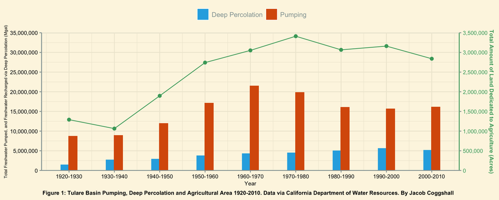

```r
ggplot() +                                                          #Calling ggplot
  theme_solarized() +                                                    #Setting the theme for the plot for visibility of data
  geom_col(data = tulare_water,                                    #Calling columns as the plot, and calling the correct df
           aes(x = year, y = withdrawals,                           #Setting our x and y axis
               fill = type),                                        #Filling in with our pumping and percolation data
           position = position_dodge(3.5),                            #Setting the distance between our bars
           width = 4)+                                              #Setting the width of our bars
  scale_fill_manual(values = c(deep_percolation = "#26AEE3",        #Setting the colors of our percolation bar
                               pumping = "#D95C09"),                #Setting the colors of our pumping bar
                    labels = c("Deep Percolation",                  #Labeling our legend titles
                            "Pumping")) +                           #Labeling our other legend title
  geom_line(data = tulare_basin_ag,                                #Calling the function for our trendline
            aes(x = time,                                           #Setting the x data for our trendline
                y = ag_area_ac*10),                               #Setting and scaling the y data for our trendline
            color = "#46A669")+                                     #Setting the color of our trendline
  geom_point(data = tulare_basin_ag,                               #Calling the specific points that will appear on our line
             aes(x = time,                                          #Setting the x data for our points
               y = ag_area_ac*10),                                #Setting and scaling the y data for our points
             color = "#46A669",                                     #Setting the color of our points
             size = 2) +                                            #Setting the size of our points
  scale_x_continuous(breaks = c(1920,                               #Setting the ticks for the data on our x axis
                                1930,
                                1940,
                                1950,
                                1960,
                                1970,
                                1980,
                                1990,
                                2000),
                     labels = c("1920-1930",                        #Labeling the ticks for the data on our x axis
                                "1930-1940",
                                "1940-1950",
                                "1950-1960",
                                "1960-1970",
                                "1970-1980",
                                "1980-1990",
                                "1990-2000",
                                "2000-2010")) +
  scale_y_continuous(breaks = scales::pretty_breaks(n = 10),       #Setting the breaks for our y axis
                     labels = scales::comma,                       #Setting what is gonna make those breaks
                     limits = c(0, 35000000),                      #Setting the limit for our y axis
                    expand = c(0, 0),                              #making our bars flush with the x axis
                    sec.axis = sec_axis( trans=~./10,            #Creating a second y axis, and scaling it with our trendline
                                          breaks = scales::pretty_breaks(n = 10),     #Setting the breaks for our y axis
                                          name="Total Amount of Land Dedicated to Agriculture (Acres)",  #labeling our second axis
                                          labels = scales::comma)) +    #Setting what is gonna make those breaks
  theme(axis.line.y.right = element_line(color="#46A669")) +       #Setting the color of the additional axis
  labs(x = "Year",                                                 #Setting the x axis label of our Plot
      y = "Total Freshwater Pumped, and Freshwater Recharged via Deep Percolation (Mgal)", #Setting the y axis label of our Plot
      labels = scales::comma,  #Scaling the labels with the commas
      caption = "Figure 1: Tulare Basin Pumping, Deep Percolation and Agricultural Area 1920-2010. Data via California Department of Water Resources. By Jacob Coggshall",      #Setting the caption of the plot
      fill = "") +
 # display.brewer.all(colorblindFriendly = TRUE) +                                   #Add in the color brewer function
  #scale_colour_brewer(palette = "GuPN")                          #Set the pallet
  #Color brewer is bad
  theme(axis.text = element_text(color = "black",                 #Setting the size, color, and font of our axis titles and legend
                                  size = 8),
        axis.title.x = element_text(color = "black",
                                       size = 8),
       axis.title.y.left = element_text(color = "black",
                                   size = 6),
       axis.title.y.right = element_text(color = "#46A669",
                                         size = 8,
                                         face = "bold"),
       axis.text.y.right = element_text(color = "#46A669",
                                        size = 8),
       plot.caption = element_text(hjust = 0.15,
                                   color = "black",
                                   face = "bold",
                                   size = 8),
       legend.title = element_text(size = 8),
       legend.position = "top")
```

**Q2: What is most (or least) surprising?** That the deep percolation hasn’t significantly decreased over time due to this increase in pumping and land distribution. I thought it would decrease.

**Q3: What three new functions did you implement to support visualization of the data? Explain what each of them does.** I used theme_solarized which I imported from the ggthemes package. This supports visualization by really contrasting well with the green line set for agricultural land. I used the distinct() function to select just the exact column I want to evaluate for the plots. I used color brewer, imported the package, then realized it was awful so I commented it out and used a hex color.